# Homework 06

## Question 1: Compare KNN and logistic regression

Use breast-cancer.csv, which contains 569 cases from the [Wisconsin Diagnostic Breast Cancer dataset](https://archive.ics.uci.edu/dataset/17/breast%2Bcancer%2Bwisconsin%2Bdiagnostic). Predict `y` (1 for malignant and 0 for benign) using `mean_radius`, `mean_texture`, and `mean_smoothness`.

Set a random seed and randomly split the observations into 70% training and 30% test data. Use the same split for every model. Standardize the predictors using the training means and standard deviations, and apply the same transformations to the test data.

Fit ordinary logistic regression with an intercept and no penalty, and KNN with Euclidean distance, equal neighbor weights, and

$$k\in\{5,15,25,35,45\}.$$

Using the estimated probabilities for `y = 1` on the test data, plot all six ROC curves in one figure and report their AUC values. Which of the six fitted models do you prefer? Give a brief justification based on your results.

### My answer

I used the supplied `breast-cancer-split.csv` so the 70/30 split is reproducible (398 train, 171 test). For KNN the predicted probability of malignancy is just the fraction of malignant cases among the k neighbors, which `predict_proba` gives directly.

```
              Model  Test AUC
Logistic regression    0.9746
         KNN, k = 5    0.9329
        KNN, k = 15    0.9480
        KNN, k = 25    0.9599
        KNN, k = 35    0.9727
        KNN, k = 45    0.9741
```

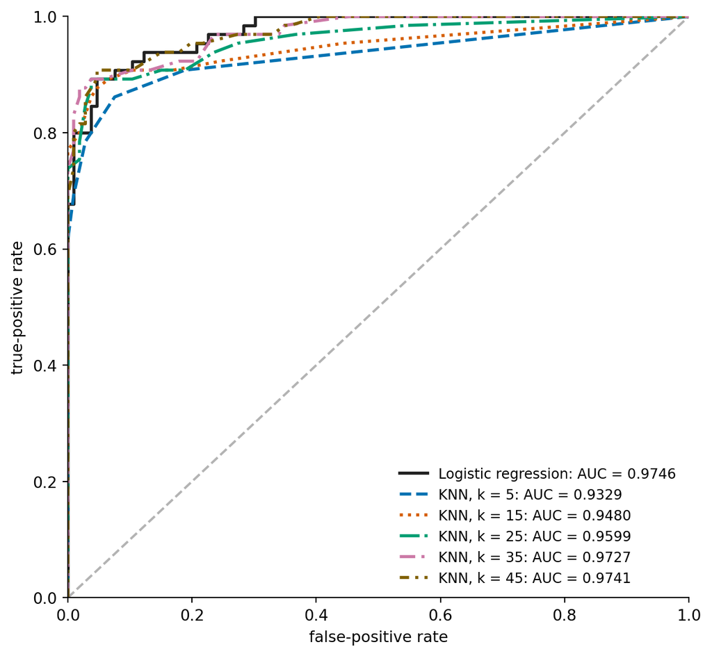

```python
from pathlib import Path
import numpy as np, pandas as pd, matplotlib.pyplot as plt
from sklearn.linear_model import LogisticRegression
from sklearn.neighbors import KNeighborsClassifier
from sklearn.metrics import roc_curve, roc_auc_score

data = pd.read_csv("data/breast-cancer.csv")
split = pd.read_csv("data/breast-cancer-split.csv")
train = data.loc[split["split"].eq("train")]
test = data.loc[split["split"].eq("test")]
predictors = ["mean_radius", "mean_texture", "mean_smoothness"]

# standardize with training mean/sd, apply same transform to test
xb = train[predictors].mean(); s = train[predictors].std(ddof=1)
X_train = ((train[predictors] - xb) / s).to_numpy()
X_test = ((test[predictors] - xb) / s).to_numpy()
y_train = train["y"].to_numpy(); y_test = test["y"].to_numpy()

fit = LogisticRegression(penalty=None, solver="lbfgs", fit_intercept=True,
                         tol=1e-10, max_iter=1000).fit(X_train, y_train)
k_values = [5, 15, 25, 35, 45]
names = ["Logistic regression"] + [f"KNN, k = {k}" for k in k_values]
p_test = np.empty((len(y_test), len(names)))
p_test[:, 0] = fit.predict_proba(X_test)[:, 1]
for m, k in enumerate(k_values):
    kn = KNeighborsClassifier(n_neighbors=k, weights="uniform", metric="euclidean", algorithm="brute").fit(X_train, y_train)
    p_test[:, m+1] = kn.predict_proba(X_test)[:, 1]

auc = [roc_auc_score(y_test, p_test[:, m]) for m in range(len(names))]
print(pd.DataFrame({"Model": names, "Test AUC": np.round(auc, 4)}).to_string(index=False))

colors = ["#222222", "#0072B2", "#D55E00", "#009E73", "#CC79A7", "#806000"]
styles = ["-", "--", ":", "-.", (0,(5,2,1,2)), (0,(3,2,1,2,1,2))]
fig, ax = plt.subplots(figsize=(6.5, 6))
ax.plot([0,1], [0,1], color="0.7", linestyle="--")
for m, nm in enumerate(names):
    fpr, tpr, _ = roc_curve(y_test, p_test[:, m])
    ax.plot(fpr, tpr, color=colors[m], linestyle=styles[m], linewidth=2,
            label=f"{nm}: AUC = {auc[m]:.4f}")
ax.set(xlim=(0,1), ylim=(0,1), xlabel="false-positive rate", ylabel="true-positive rate")
ax.legend(loc="lower right", frameon=False, fontsize=9)
ax.spines[["top","right"]].set_visible(False)
fig.tight_layout(); plt.show()
```

On this split I’d go with logistic regression. Its test AUC is 0.9746, the highest of the six, and it’s the simplest model (three coefficients plus an intercept, nothing to store). KNN at k=45 is basically tied at 0.9741 and k=35 is close at 0.9727, but the small neighborhoods are clearly worse (0.9329, 0.9480, 0.9599 for k=5,15,25). The pattern makes sense: bigger neighborhoods average out noise and rank the test cases better, while k=5 is too jumpy. That said, this is one split and AUC only measures ranking, not accuracy at a fixed cutoff, so I wouldn’t claim logistic is universally better. A real selection would tune k by CV inside the training set first, then check the winner on a held-out test set once.

## Question 2: Training and test ROC curves

Use the same data, training/test split, and standardization as in Question 1. Fit KNN with Euclidean distance, equal neighbor weights, and

$$k\in\{1,3,5,10,20\}.$$

Use each fitted model to estimate probabilities for both the training and test observations. For training predictions, include each observation itself among its $k$ nearest neighbors.

For each $k$, use a separate panel to show the training and test ROC curves together. Report both AUC values.

Explain the difference between training and test performance and how it changes with $k$. In particular, explain what happens at $k=1$ and why training performance may not reflect performance on new observations.

### My answer

Same split and standardization as Q1. For training predictions I pass `X_train` back in as the query set, so each point is its own nearest neighbor.

```
 k  Training AUC  Test AUC
 1        1.0000    0.8764
 3        0.9905    0.9138
 5        0.9847    0.9329
10        0.9862    0.9446
20        0.9880    0.9586
```

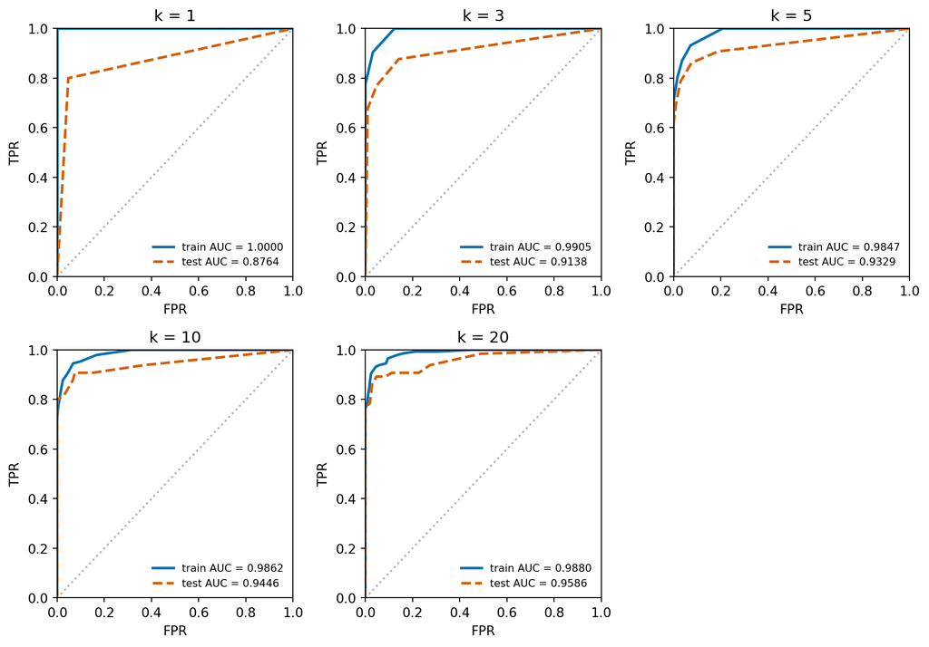

```python
k_values = [1, 3, 5, 10, 20]
p_train = np.empty((len(y_train), len(k_values)))
p_test2 = np.empty((len(y_test), len(k_values)))
auc_train = np.empty(len(k_values)); auc_test = np.empty(len(k_values))
for m, k in enumerate(k_values):
    kn = KNeighborsClassifier(n_neighbors=k, weights="uniform", metric="euclidean", algorithm="brute").fit(X_train, y_train)
    p_train[:, m] = kn.predict_proba(X_train)[:, 1]   # each obs is its own neighbor
    p_test2[:, m] = kn.predict_proba(X_test)[:, 1]
    auc_train[m] = roc_auc_score(y_train, p_train[:, m])
    auc_test[m] = roc_auc_score(y_test, p_test2[:, m])
print(pd.DataFrame({"k": k_values, "Training AUC": np.round(auc_train,4),
                    "Test AUC": np.round(auc_test,4)}).to_string(index=False))

fig, axes = plt.subplots(2, 3, figsize=(10, 7))
for m, k in enumerate(k_values):
    ax = axes.flat[m]
    fpr, tpr, _ = roc_curve(y_train, p_train[:, m])
    ax.plot(fpr, tpr, color="#0072B2", linewidth=2, label=f"train AUC = {auc_train[m]:.4f}")
    fpr, tpr, _ = roc_curve(y_test, p_test2[:, m])
    ax.plot(fpr, tpr, color="#D55E00", linestyle="--", linewidth=2, label=f"test AUC = {auc_test[m]:.4f}")
    ax.plot([0,1], [0,1], color="0.7", linestyle=":")
    ax.set(title=f"k = {k}", xlim=(0,1), ylim=(0,1), xlabel="FPR", ylabel="TPR")
    ax.legend(loc="lower right", frameon=False, fontsize=8)
axes.flat[-1].set_visible(False)
fig.tight_layout(); plt.show()
```

## Question 3: Peer evaluation of Homework 5

You will receive two Homework 5 submissions to review. The instructor’s GitHub account, **rqzhu-aide**, will open a **GitHub Issue** in the repository containing your Homework 5 submission. It will contain links to two other students’ repositories, where you can find their submitted homework reports.

Open your repository’s **Issues** tab on GitHub to find the assignment. You may ask AI to explain GitHub Issues or help you locate the assignment.

Choose **one specific mistake or item for improvement** from any question in either report.

1. **Identify the mistake or item for improvement.** State which report and question you selected, and briefly describe what is wrong or could be improved. Examples include incorrect code, a calculation error, a misinterpretation of results, a plot that could communicate the findings more clearly, or anything else you think could be done better.
2. **Explain your assessment.** Quote the relevant text, code, or figure caption exactly. Explain why the selected answer is incorrect or how it could be improved, referring to its reasoning, calculations, code, figures, or interpretation. **Complete this part yourself, without AI assistance.**
3. **Provide a correction.** Write a corrected or improved answer to the selected question, including any calculations, code, or figures needed.

After completing your review, **open a GitHub Issue in the repository containing the report you selected**. Identify the report and question, and include your assessment and a detailed revision plan explaining what the author should change and why. Include a link to your posted GitHub Issue in your Homework 6 answer.

### My answer

**1. Identify the mistake or item for improvement.**

Report selected: ousher17’s report. Question selected: Question 1, part a.

In the Q1a loop, the KNN predictions are written to a variable called `pred_one`, but the vector that was allocated and later printed is `pred_x0`. The loop never fills `pred_x0`, so the table that gets displayed shows the zero-initialized vector instead of the actual KNN predictions. The reported predictions for every k are therefore wrong.

**2. Explain your assessment.**

> `pred_one[j] <- knn.reg(train = X, test = matrix(x0, nrow = 1), y = Y, k = k)$pred`

The loop assigns each prediction to `pred_one[j]`, but `pred_one` is never created anywhere in the code. The vector that was allocated before the loop is `pred_x0 <- numeric(length(k_val))`, and that same `pred_x0` is what the final `data.frame(k = k_val, prediction = pred_x0)` prints. Because the loop writes to the wrong name, `pred_x0` is never updated, so the displayed table is just the zero vector it was initialized to. The predictions shown for part a aren’t the real KNN estimates at x0, so there’s no valid output to reason about for the rest of the question. The fix is to make the loop write to the same vector that gets printed.

**3. Provide a correction.**

The fix is a one-line variable-name correction inside the loop (`pred_one[j]` to `pred_x0[j]`):

```r
library(FNN)
x0  <- c(0.5, 0.7, 1)
fx0 <- 0.5*x0[1] + sin(x0[2]) - 0.3*x0[3]^2   # = 0.594218
set.seed(42302)
n <- 400
X <- matrix(rnorm(n * 3), nrow = n, ncol = 3)
epsilon <- rnorm(n, mean = 0, sd = 0.1)
Y <- 0.5*X[,1] + sin(X[,2]) - 0.3*X[,3]^2 + epsilon

k_val <- seq(1, 29, by = 2)
pred_x0 <- numeric(length(k_val))
for (j in seq_along(k_val)) {
  pred_x0[j] <- knn.reg(
    train = X,
    test  = matrix(x0, nrow = 1),
    y     = Y,
    k     = k_val[j]
  )$pred
}
data.frame(k = k_val, prediction = pred_x0)
```

Link to posted GitHub Issue: https://github.com/ousher17/stat432-fall2026/issues/2